[O’Hara on GitHub](https://github.com/oharac)

# Parse fishing threats

Compiled on Thu Apr 25 18:49:09 2019 by ohara

```r
source(here::here('common_fxns.R'))

### provenance tracking
library(provRmd); prov_setup()
```

# 1 Summary

Examine threats to marine species as determined by IUCN threat classifications and text dismemberment of IUCN species narratives. Crosswalk these against CHI threats.

# 2 Data Sources

### 2.0.1 IUCN Red List

# 3 Methods

## 3.1 Check for fishing threats by threat code

Categories of threats from fishing and harvesting aquatic resource include targeted, bycatch (unintentional effects), persecution/control, and unknown:

| code | desc |
| --- | --- |
| 5.4 | Fishing & harvesting aquatic resources |
| 5.4.1 | Fishing & harvesting aquatic resources: Intentional use: subsistence/small scale (species being assessed is the target)[harvest] |
| 5.4.2 | Fishing & harvesting aquatic resources: Intentional use: large scale (species being assessed is the target)[harvest] |
| 5.4.3 | Fishing & harvesting aquatic resources: Unintentional effects: subsistence/small scale (species being assessed is not the target)[harvest] |
| 5.4.4 | Fishing & harvesting aquatic resources: Unintentional effects: large scale (species being assessed is not the target)[harvest] |
| 5.4.5 | Fishing & harvesting aquatic resources: Persecution/control |
| 5.4.6 | Fishing & harvesting aquatic resources: Motivation Unknown/Unrecorded |

Variables in the threat report include timing, scope, severity, and score. Filtering rules to determine whether a species is “impacted” by fishing pressure and thus benefits from removal of fishing pressure:

- `timing` is not “Past, Unlikely to Return”
- `scope` is any scope (i.e. `NA`, “Unknown”, “Minority (<50%)”, “Majority (50-90%)”, “Whole (>90%)”)
- `score` is greater than some threshold?
  - high impact is `score_num` of 8 or greater
  - medium impact is `score_num` of 6 or 7
  - low is 3-4-5
  - no/negligible is 0 or 1 (2 does not appear in this subset of data)
- If no valid `score` then look at `severity`; perhaps choose some threshold e.g. “rapid” or “very rapid” declines:
  - NA, “Unknown”
  - “No decline”, “Negligible declines”
  - “Slow, Significant Declines”
  - “Rapid Declines”, “Very Rapid Declines”
  - “Causing/Could cause fluctuations”

What species are represented in this filtered set? what is the distribution of extinction risk categories included?

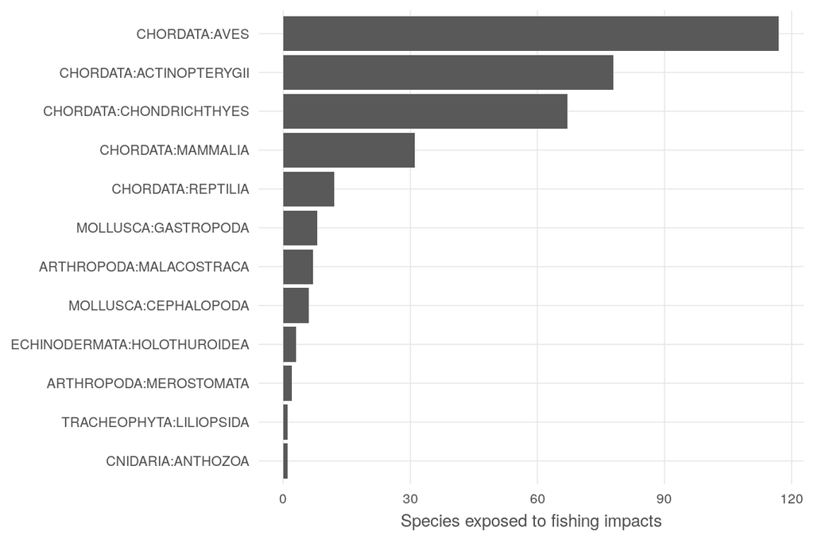

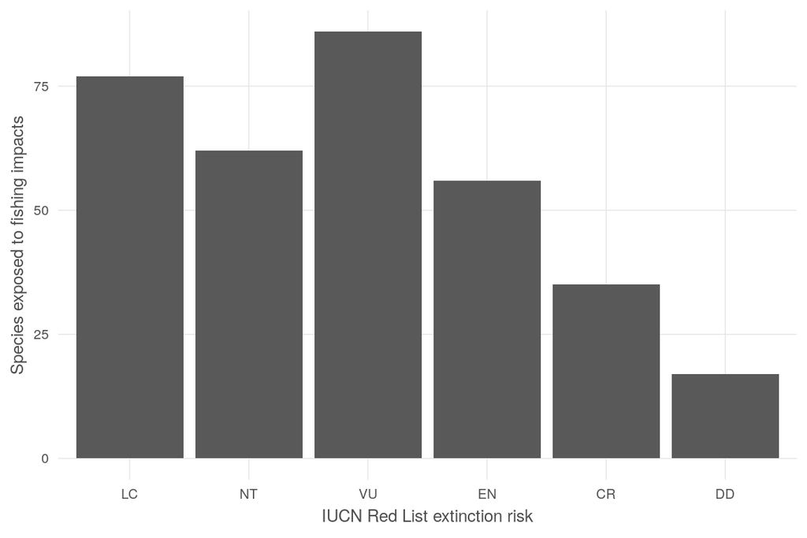

## 3.2 Check for bycatch and gear instances in narratives

Since trawl surveys are often used for research, we can look for “trawl” but not “survey” as a pattern; are there any other troublesome patterns?

Potential combinations to exclude:

- trawl survey
- fishery-independent trawl, exploratory trawl, experimental trawl
- research trawl, scientific trawl
- trawl sample, trawl experiment, trawl research

## 3.3 Combine threat assessment with narrative threats

Examine the combination of species with fishing as a major threat, with the gear type breakdown from the narratives. By `inner_join`ing the narrative info to the threat classifications, only species with fishing listed as a major threat are kept, though some of these may not have narratives with which to classify gear types (particularly for LC species).

This table is not saved but is easy to recreate from the inputs.

|  | iucn_sid | severity | score_num | code | desc | sciname | bycatch_count | longline_count | trawl_count | seine_count | gillnet_count |
| --- | --- | --- | --- | --- | --- | --- | --- | --- | --- | --- | --- |
| 1 | 2060 | Causing/Could cause fluctuations | 5 | 5.4.2 | Intentional use: (large scale) [harvest] | Arctocephalus pusillus | 3 | 0 | 4 | 0 | 0 |
| 2 | 2066 | Causing/Could cause fluctuations | 5 | 5.4.2 | Intentional use: (large scale) [harvest] | Arctocephalus pusillus ssp. pusillus |  |  |  |  |  |
| 3 | 3590 | Causing/Could cause fluctuations | 6 | 5.4.4 | Unintentional effects: (large scale) [harvest] | Callorhinus ursinus |  |  |  |  |  |
| 4 | 3898 | Rapid Declines | 7 | 5.4.1 | Intentional use: (subsistence/small scale) [harvest] | Carettochelys insculpta |  |  |  |  |  |
| 5 | 3898 | Very Rapid Declines | 8 | 5.4.2 | Intentional use: (large scale) [harvest] | Carettochelys insculpta |  |  |  |  |  |
| 6 | 4160 | Slow, Significant Declines | 6 | 5.4.4 | Unintentional effects: (large scale) [harvest] | Cephalorhynchus eutropia | 3 | 1 | 0 | 0 | 3 |
| 7 | 4161 | Causing/Could cause fluctuations | 7 | 5.4.4 | Unintentional effects: (large scale) [harvest] | Cephalorhynchus heavisidii | 3 | 0 | 4 | 4 | 2 |
| 8 | 6229 | Rapid Declines |  | 5.4.2 | Intentional use: (large scale) [harvest] | Dalatias licha | 3 | 5 | 7 | 0 | 5 |
| 9 | 6229 | Causing/Could cause fluctuations | 5 | 5.4.3 | Unintentional effects: (subsistence/small scale) [harvest] | Dalatias licha | 3 | 5 | 7 | 0 | 5 |
| 10 | 6229 | Causing/Could cause fluctuations | 6 | 5.4.4 | Unintentional effects: (large scale) [harvest] | Dalatias licha | 3 | 5 | 7 | 0 | 5 |

[output cut: 484 more lines]